# econ2200Ch06 slides

## ECON2200H

### Introduction to Statistics for Economics and Management

### 2020 Winter Term

### Week 05: Random Variables and Their Distributions (continued)

#### 3 February 2020

## Recap

- Discrete random variables
- Probability mass function; cumulative distribution function
- Independence of random variables
- Mean and variance of random variables
- The mean and variance of functions of random variables
- Important distributions of discrete random variables
  - Geometric distribution
  - Bernoulli distribution
  - Binomial distribution
  - Poisson distribution

### Reading: Chapter 6 of textbook.

## Outline

- Continuous random variables.
- Uniform distribution.
- Normal distribution.

## 1. Continuous random variables and their distributions

- A random variable is **continuous** if it takes on a continuum of values rather than a finite number of values.
- Random variable $X$ is said to have a continuous distribution with **probability density function** or simply **density function** $f$ if for all $a \le b$, $$P(a\le X \le b) = \text{the area under the graph of } f(x) \text{ between } a \text{ and } b.$$
- Draw a graph showing $P(a\le x \le b)$.

#### Properties of density function

- Heuristically, we can think of density function as the limit of probability mass function when the distance between two consecutive values is infinitesimal.
- For a continuous random variable $X$, the probability of any value $X=x$ is zero. That is, $P(X=x)=0$ for any value of $x$.
- Why? $P(X=x) = \lim_{\Delta x \rightarrow 0} P(x \le X \le x+\Delta x)$ which equals zero (as $\Delta x$ approaches to zero), since the area under the graph of $f(x)$ between $x$ and $x$ is zero.
- But $f(x)$ tells the likelihood of $X$ being near $x$.
- A density function $f(x)$ satisfies: i) $f(x)\ge 0$; ii) The area under the graph of $f(x)$ between $-\infty$ and $\infty$ is one.
- **Cumulative distribution function** (cdf) of a continuous random variable $X$ is $$F(x) = P(X\le x).$$
- This means that the cdf of $X$ is the area of the graph under $f(x)$ between $-\infty$ and $x$.
- The probability that $X$ falls into an interval $[a,b]$ is $$P(a \le X \le b) = F(b) - F(a).$$
- The **expected value** or **mean** of a continuous random variable $X$ is defined in the same spirit of that for a discrete random variable.
  - It requires integral, we thus do not give the mathematical expression.
- If $Y = a X+b$ where $a, b$ are finite constants, then $EY = a EX$.
- For any two random variables $X_1$ and $X_2$, $E[X_1+X_2] = E X_1 + EX_2$.
- The variance of $X$ is the expected value of $(X - EX)^2$.
- $\text{var}(X) = E[X^2] - (E[X])^2$.
- If $Y = a X + b$ where $a, b$ are finite constants, then $\text{var}(Y) = a^2 \text{var}(X)$.
- If random variables $X_1$ and $X_2$ are independent, then $$\text{var}(X_1+X_2) = \text{var}(X_1) + \text{var}(X_2).$$

## 2. Two continuous distribution functions

- The uniform distribution function.
- The normal distribution function.

### 2-1. The uniform distribution

- A continuous random variable $X$ on the finite interval $[a,b]$ has a **uniform probability density function** with parameter $a$ and $b$ if $$f(x) = \left\{\begin{array}{ll} \frac{1}{b-a}, & \text{for } a\le x \le b; \\ 0, & \text{otherwise} \end{array} \right.$$
- The cumulative distribution function of a uniform random variable $X$ is $F(x) = P(X\le x) = \frac{x-a}{b-a}$ if $a \le x \le b$.
- The mean of a uniform random variable is $\mu = \frac{a+b}{2}$.
- The variance of a uniform random variable is $\sigma^2 = \frac{(b-a)^{2}}{12}$.
- Draw a graph of the uniform density function $f(x)$ where $x \in [a,b]$.
- Show that the probability $P(X \le x)$ is the area under the graph of $f(x)$ between $a$ and $x$.
- Show that $P(a \le X \le b) = 1$.
- Show that $P(X=x)$ for any $x \in [a,b]$ is zero.
- Show that $P(X\le x) = \frac{x-a}{b-a}$, the area under the graph of $f(x)$ between $a$ and $x$.

### 2-2. The normal distribution

- A continuous random variable $X$ has a **normal probability density function** $f$ with parameters $\mu$ and $\sigma^2$, if $f(x)$ takes the following form $$f(x) = \frac{1}{\sigma \sqrt{2\pi}} e ^{-\frac{(x-\mu)^2}{2\sigma^2}}, \text{ for } -\infty < x < \infty.$$
- Here, $\pi = 3.1415926$.
- We then call $X$ a normal random variable, or that $X$ is normally distributed.
- The mean of $X$ is $\mu$. The variance of $X$ is $\sigma^2$.
- As we have seen, variance is a measure of the dispersion of a distribution.
- Let $X$ have a normal probability density function $f(x)$ with parameters $\mu$ and $\sigma^2$. Let $Z = a X +b$, then $Z$ also has a normal density function with parameters $a \mu +b$ and $a^2 \sigma^2$.
- In particular, the random variable $Z = \frac{X-\mu}{\sigma}$ has a **standard normal density function** with parameters $0$ and $1$.
- The standard normal density function is given by $$\phi(z) = \frac{1}{\sqrt{2\pi}} e ^{-\frac{z^2}{2}}, \text{ for } -\infty < z < \infty.$$
- The normal distribution is **bell-shaped**.
- It is symmetric around the mean value of $X$. The mean and median equal.

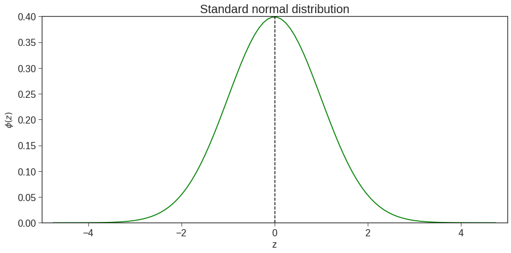

- **Example**. Normal distribution with different dispersions.

[figure not shown]

#### Cumulative distribution function of a standard normal random variable

- The cdf of the standard normal random variable $Z$ is the area under the graph of $\phi(z)$ between $-\infty$ and $z$.
- This cdf has no closed form, we use the notation $\Phi(z)$.
- The probability $P(Z \le z)$ equals the area under the graph of $\phi(z)$ between $-\infty$ and $z$. That is, $P(Z\le z) = \Phi(z)$.
- Draw $\Phi(z)$. Shown that the area to the left of $z=0$ is 0.5.

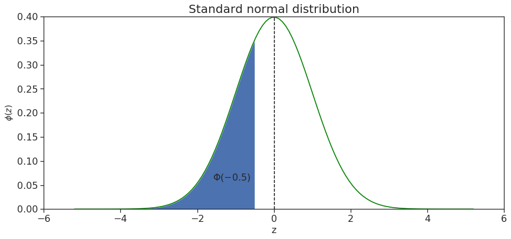

- **For any normally distributed random variable $X$ with parameters $\mu$ and $\sigma^2$, the cdf of $X$ can be obtained using the standard normal cdf $\Phi(z)$ through the linear transformation $Z = \frac{X - \mu}{\sigma}$**.
- The cdf of $X$ represents $P(X \le x)$. That is, $F(x) = P(X \le x)$.
- $P(X \le x) = P((\sigma Z + \mu) \le x) = P(Z \le \frac{x-\mu}{\sigma}) = P(Z \le z) = \Phi(z)$, where $z = \frac{x-\mu}{\sigma}$.
- Following the definition of cdf, $P(X>x) = 1- P(X\le x) = 1 - \Phi(z)$, where again $z = \frac{x-\mu}{\sigma}$.
- **Example**. Suppose that the box weight of Sugar Yummies $X$ follows a normal distribution with a mean of 283 grams and a standard deviation of 1.6 grams. That is, $\mu = 283$ and $\sigma=1.6$.
- What is the probability that boxes of Sugar Yummies have a weight between 283 grams and 285.4 grams?
- That is, $P(\mu < X < 285.4) = ?$
- Let $Z = \frac{X-\mu}{\sigma}$. We knew that $Z$ has a standard normal distribution.
- Then, $P(283 <X < 285.4) = P\left(0 < \frac{X-283}{\sigma} < \frac{285.4 - 283}{\sigma}\right) = P(0<Z<1.5)$.
- $P(0<Z<1.5) = \Phi(1.5) - \Phi(0)$, which is the area under the graph $\phi(z)$ for $0<z<1.5$.
- Mathematicians have calculated $\Phi(1.5) - \Phi(0)$. Table shows the area between 0 and a positive value $z$.
- How to read the table: $P(0<Z<1.96) = 0.475$. $P(0<Z<1.75) = 0.4599$.

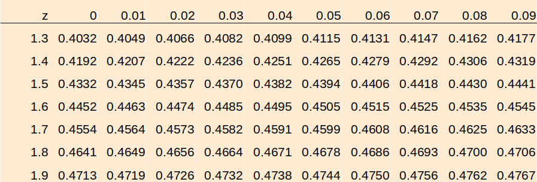

- From the table, $\Phi(1.5) - \Phi(0) = 0.4332$, then $P(283 <X < 285.4) = 0.4332$.

[figure not shown]

### 2-3. The empirical rule for normally distributed random variables

[figure not shown]

- The rule says: $P(-1<Z<1) = 0.6826$, which is the area under $\phi(z)$ between -1 and 1 (e.g., within one standard deviation). Note: standard deviation of $Z$ is one.
- Another case: $P(-2<Z<2) = 0.9544$, which is the area under $\phi(z)$ between -2 and 2 (e.g., within two standard deviations).
- For a random variable $X$ that has a general normal distribution with parameters $\mu$ and $\sigma^2$:
  - $P(\mu - \sigma <X< \mu + \sigma) = 0.6826$, the probability of $X$ falling within one standard deviation around mean is 0.6826.

### 2-4. Percentiles of a normally distributed random variable

- For a given number $p$ with $0<p<1$, the **$100p$ percentile** of a normally distributed random variable $X$ is defined as the number $x_p$ for which $$P(X\le x_p) = p.$$
- **Example**. In a flash bulbs company, let $X$ represent the number of minutes of bulbs' duration, which has a normal distribution. The mean duration is $\mu = 107000$ minutes, and the standard deviation is $\sigma=3100$ minutes.
- Further, let $x_p$ be the minimum number of minutes of bulbs, below which bulbs must be replaced.
- What is $x_p$ if no more than $3\%$ of bulbs are replaced? That is, find $x_p$ such that $P(X \le x_p)=0.03$.
- In this graph, label $X$ should be $x_p$.

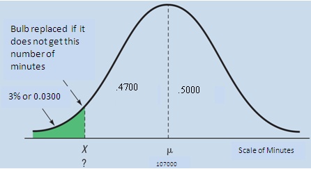

### 2-5. Using normal distribution to approximate binomial distribution

- When the number of Bernoulli trials, $n$, is large, the binomial distribution can be approximated with the normal distribution.
- Graph shows binomial distribution with $n=100$ and $p=0.5$ and normal distribution $N(50, 25)$.

[figure not shown]